# CYPLAN 255 Final Project

## Question

What is the relationship between the siting of natural gas power plants and poverty?

## Key Findings

As we view the map of the power plants, we see that most natural gas power plants and wind farms are located in Southern California which may be due to the large amount of people living there.

## Background

Research has revealed that gas infrastructure is disproportionately near low-income neighborhoods (1). The relationship raises a crucial question when discussing the siting of power plants: are these communities living there before or after a power plant has been approved for siting? While my analysis does not seek to determine which came first, it does delve into the poverty rate by census tract and the relationship between natural gas power plant siting. This analysis examines the relationship between California households living in poverty and those residing in a census tract where natural gas power plants are located. The Census defines poverty as families with income below the poverty threshold. In 2022, the official poverty rate was 11.5 percent, with 37.9 million people in poverty (2).

Natural gas power plants provide Californians with cheap, low-emission, and reliable electricity. They are also essential to ensure the electric grid provides electricity when solar and wind cannot generate electricity during low sunlight and wind. As of 2022, natural gas power plants in California generated 96 gigawatt hours (GWh) from the 39 gigawatts (GW) of capacity, making up 47% of in-state electric generation (3).

Although natural gas power plants have made up much of California's electric generation portfolio, burning natural gas is still burning fossil fuels. Natural gas power plants have countless negative impacts. Impacts include extraction of resources, transportation of resources, and local emissions. The combustion of natural gas results in emissions of nitrogen oxides (NOx), sulfur, mercury, and particulates (4). The resulting emissions harm people's health and the environment, contributing to smog (5). Illness from pollutants includes respiratory symptoms, cardiovascular disease, and cancer (6).

California Governor Gavin Newsome recently called for extending three natural gas power plants in Southern California, slated to retire in 2020 (7). The planned retirement of power plants using seawater-cooling techniques kills marine life (8). However, the power plants received three-year extensions due to rolling blackouts in the summer of 2020. Now, the extension has been extended again to 2026. The communities nearby have been vocal about opposing the extension, many of whom are farm workers. As California works to reaches its 100% clean energy goals, retiring natural gas power plants will be essential to ensure those disproportionately burdened by pollution receive adequate access to clean, pollutant-free electricity.

## Methodology

I begin by examining power plants recorded by the California Energy Commission's (CEC) Quarterly Fuels and Energy Report, which tracks the capacity and generation of power plants operating within California or a control area with end users inside California (9). By grouping the energy source by capacity, we determine that natural gas power plants have the highest capacity out of any other energy resource. I demonstrate this with a table, bar chart, and a hexbin map.

Next, I utilized the Census API to collect data from the American Community Survey 5-Year Data 2019. I selected the Ratio of Income to Poverty Level fields C17002_001E, C17002_002E, C17002_003E, and population field B01003_001E. I estimate the poverty rate by dividing C17002_002E (ratio of income to poverty in the past 12 months, < 0.50) and C17002_003E (ratio of income to poverty in the past 12 months, 0.50 - 0.99) by census tract population (10).

With the Census data on poverty rates, I joined the geodataframe with California natural gas power plants and wind farms.

Using a kernel density plot, I visualize the distribution of census tracts by poverty rate for California, census tracts intersecting natural gas power plants, and census tracts intersecting wind farms.

Then, I calculated the average poverty rates by census tracts for California, census tracts intersecting natural gas power plants, and census tracts intersecting wind farms. I calculated the max poverty rate accounting for outliers for census tracts intersecting natural gas power plants and wind farms. Also, I calculated the count of power plants intersecting census tracts.

Next, I demonstrate on a point map the location of power plants colored by poverty rate.

I then created a correlation matrix to determine whether there is any relationship between the size of a power plant and the poverty rate.

Lastly, I used the Mapbox API to demonstrate power plants by poverty rate through a color ramp and capacity by circle size for both natural gas power plants and wind farms.

## Reference

(1) https://blog.ucsusa.org/vivian-yang/reliance-on-gas-power-plants-fuels-inequity/#:~:text=Gas%20infrastructure%20is%20inequitably%20sited,demographic%20disparities%20near%20gas%20infrastructure.

(2) https://www.census.gov/library/publications/2023/demo/p60-280.html

(3) https://www.energy.ca.gov/data-reports/energy-almanac/california-electricity-data/electric-generation-capacity-and-energy

(4) https://www.ucsusa.org/resources/environmental-impacts-natural-gas

(5) https://ww2.arb.ca.gov/our-work/topics/health

(6) https://www.atsdr.cdc.gov/interactionprofiles/ip05.html

(7) https://calmatters.org/environment/2023/08/southern-california-natural-gas-plants-remain-open/#:~:text=The%20plants%20had%20been%20slated,been%20extended%20again%20%E2%80%94%20through%202026.

(8) https://www.waterboards.ca.gov/publications_forms/publications/factsheets/docs/oncethroughcooling_20200818.pdf

(9) https://www.energy.ca.gov/data-reports/energy-almanac/california-electricity-data/quarterly-fuel-and-energy-report-qfer-data

(10) https://pygis.io/docs/d_access_census.html

```python
import pandas as pd
import json
import requests
from scipy.stats import pearsonr
import pprint
from datetime import datetime
import seaborn as sns
import matplotlib.pyplot as plt
import geopandas as gpd
import os
from mapboxgl.utils import *
from mapboxgl.viz import *
from census import Census
from us import states
import warnings; warnings.simplefilter('ignore')
```

```python
with open('C:\\Users\\ghuang\\OneDrive - California Energy Commission\\Documents\\Git_\\UCB_CYPLAN255_2024\\notebooks\\data\\mapbox_api_key.json', 'r') as f:
    token = json.load(f)['key']
with open('C:\\Users\\ghuang\\OneDrive - California Energy Commission\\Documents\\Git_\\UCB_CYPLAN255_2024\\notebooks\\data\\census_api_key.json', 'r') as f:
    c = json.load(f)['key']
```

```python
# Set your Census API key (replace with your actual key)
c = Census(c)
```

```python
# API of CEC's power plant location dataset
endpoint_url = "https://services3.arcgis.com/bWPjFyq029ChCGur/arcgis/rest/services/Power_Plant/FeatureServer/0/query?outFields=*&where=1%3D1&f=geojson"
```

```python
# Extract data
response = requests.get(endpoint_url)
data = json.loads(response.text)
data
powerplants = data['features']
```

```python
# Transform JSON to tabluar DF
d = {
    'CECID': [p['properties']['CECPlantID'] for p in powerplants],
    'PlantName': [p['properties']['PlantName'] for p in powerplants],
    'Retired': [p['properties']['Retired_Plant'] for p in powerplants],
    'Operator': [p['properties']['OperatorCompanyID'] for p in powerplants],
    'County': [p['properties']['County'] for p in powerplants],
    'Capacity': [p['properties']['Capacity_Latest'] for p in powerplants],
    'Units': [p['properties']['Units'] for p in powerplants],
    'Energy Source': [p['properties']['PriEnergySource'] for p in powerplants],
    'Date of Operation': [p['properties']['StartDate'] for p in powerplants],
    'Longitude': [p['geometry']['coordinates'][0] for p in powerplants],
    'Latitude': [p['geometry']['coordinates'][1] for p in powerplants],
}
df = pd.DataFrame.from_dict(d)
# UNIX to YMD
df['Date of Operation'] = df['Date of Operation'].astype("datetime64[ms]")
```

```python
df[df["PlantName"].isnull()]
df = df.dropna()
```

```python
capacity_es = df.groupby("Energy Source")[["Capacity"]].sum().reset_index().sort_values(by = "Capacity", ascending = False)
capacity_es.head(3)
```

|  | Energy Source | Capacity |
| --- | --- | --- |
| 11 | NG | 62395.94 |
| 21 | SUN | 16498.45 |
| 22 | WAT | 15873.48 |

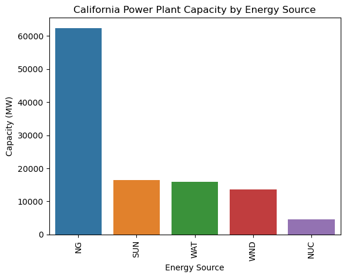

```python
capacity_es_head = capacity_es.head()
g = sns.barplot(data=capacity_es_head, x='Energy Source', y='Capacity', hue = 'Energy Source')
plt.xticks(rotation=90)
plt.ylabel("Capacity (MW)")
plt.title("California Power Plant Capacity by Energy Source");
```

```python
powerplant = gpd.read_file("https://services3.arcgis.com/bWPjFyq029ChCGur/arcgis/rest/services/Power_Plant/FeatureServer/0/query?outFields=*&where=1%3D1&f=geojson")
```

```python
tracts = gpd.read_file("https://www2.census.gov/geo/tiger/TIGER2019/TRACT/tl_2019_06_tract.zip")
```

```python
print(powerplant.crs)
print(tracts.crs)
print(type(tracts.crs))
print(tracts.crs.coordinate_system)
powerplant_proj = powerplant.to_crs(tracts.crs)
```

```
EPSG:4326
EPSG:4269
<class 'pyproj.crs.crs.CRS'>
ellipsoidal
```

```python
powerplants_per_tract = merged.groupby('GEOID').index_right.count().reset_index()
```

```python
powerplant.index.name = 'powerplant_id'
powerplant.reset_index(inplace=True)
```

```python
tracts_w_powerplant = gpd.sjoin(powerplant, tracts.to_crs(powerplant.crs), how='inner', predicate='within')
tract_counts = tracts_w_powerplant.groupby('GEOID')['powerplant_id'].count().reset_index()
tracts = pd.merge(tracts, tract_counts, on='GEOID', how='left')
tracts['powerplant_count'] = tracts['powerplant_id'].fillna(0)
tracts = tracts.clip(outlines.to_crs(tracts.crs))  # clip tract geoms to coastline
```

```python
natural_gas = powerplant[powerplant["PriEnergySource"] == "NG"]
wind = powerplant[powerplant["PriEnergySource"] == "WND"]
```

```python
ca_counties = ["Alameda", "Alpine","Amador", "Butte", "Calaveras", "Colusa","Contra Costa","Del Norte","El Dorado","Fresno","Glenn",
"Humboldt","Imperial","Inyo","Kern","Kings","Lake","Lassen","Los Angeles","Madera","Marin","Mariposa","Mendocino",
"Merced","Modoc","Mono","Monterey","Napa","Nevada","Orange","Placer","Plumas","Riverside","Sacramento","San Benito","San Bernardino","San Diego","San Francisco","San Joaquin","San Luis Obispo","San Mateo","Santa Barbara","Santa Clara","Santa Cruz","Shasta","Sierra","Siskiyou","Solano","Sonoma","Stanislaus","Sutter","Tehama","Trinity","Tulare","Tuolumne","Ventura","Yolo","Yuba"]
```

```python
natural_gas = natural_gas[natural_gas["County"].isin(ca_counties)]
wind = wind[wind["County"].isin(ca_counties)]
```

```python
natural_gas['lon'] = natural_gas.geometry.x
natural_gas['lat'] = natural_gas.geometry.y
```

```python
wind['lon'] = wind.geometry.x
wind['lat'] = wind.geometry.y
```

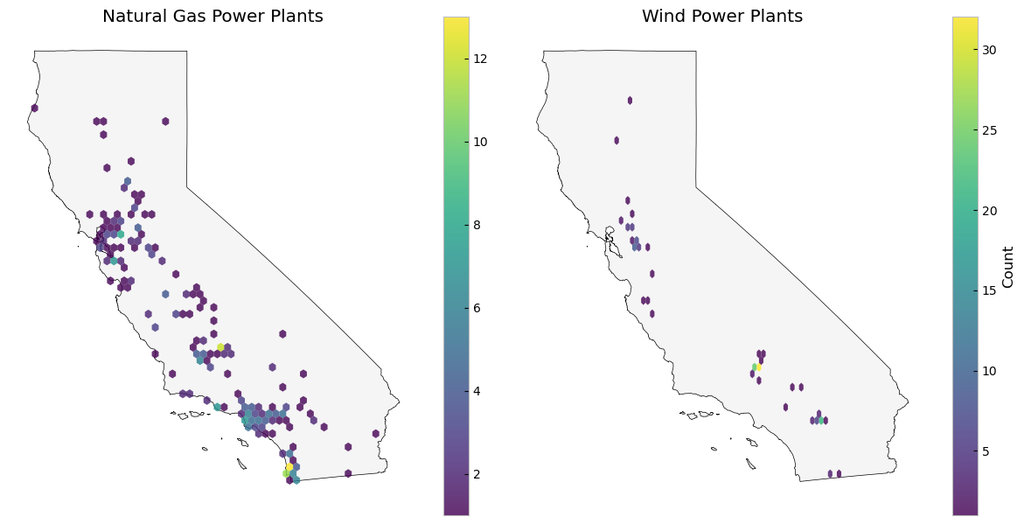

```python
fig, (ax1, ax2) = plt.subplots(1, 2, figsize=(12, 6))  # 1 row, 2 columns

# Plot Natural Gas Power Plants on the first subplot (ax1)
outlines.plot(ax=ax1, color='whitesmoke', edgecolor='black')
ax1.set_title('Natural Gas Power Plants')  # Add title to the first subplot
hb1 = ax1.hexbin(natural_gas.lon, natural_gas.lat, mincnt=1, gridsize=50, alpha=.8, lw=0)

# Plot Wind Power Plants on the first subplot (ax1)
outlines.plot(ax=ax2, color='whitesmoke', edgecolor='black')
ax2.set_title('Wind Power Plants')  # Add title to the first subplot
hb2 = ax2.hexbin(wind.lon, wind.lat, mincnt=1, gridsize=50, alpha=.8, lw=0)

# Add a colorbar for the hexbins in the second subplot (ax2)
cb = fig.colorbar(hb2, ax=ax2)
cb.set_label('Count')

cb1 = fig.colorbar(hb1, ax=ax1)

# Turn off axis for both subplots
ax1.axis('off')
ax2.axis('off')

plt.tight_layout()
plt.show()
```

```python
ca_census = c.acs5.state_county_tract(fields = ('NAME', 'C17002_001E', 'C17002_002E', 'C17002_003E', 'B01003_001E'),
                                      state_fips = states.CA.fips,
                                      county_fips = "*",
                                      tract = "*",
                                      year = 2019)
```

```python
ca_df = pd.DataFrame(ca_census)
```

```python
ca_df = ca_df[ca_df["C17002_001E"] != 0]
```

```python
ca_df["GEOID"] = ca_df["state"] + ca_df["county"] + ca_df["tract"]
```

```python
ca_df = ca_df.drop(columns = ["state", "county", "tract"])
```

```python
ca_merge = tracts.merge(ca_df, on = "GEOID")
```

```python
ca_poverty_tract = ca_merge[["STATEFP", "COUNTYFP", "TRACTCE", "GEOID", "geometry", "C17002_001E", "C17002_002E", "C17002_003E", "B01003_001E"]]
```

```python
ca_poverty_tract["Poverty_Rate"] = (ca_poverty_tract["C17002_002E"] + ca_poverty_tract["C17002_003E"]) / ca_poverty_tract["B01003_001E"] * 100
```

```python
ca_poverty_tract["Poverty_Rate"].describe()
```

```
count    7985.000000
mean       13.402192
std         9.902279
min         0.000000
25%         6.033994
50%        10.658164
75%        18.349780
max       100.000000
Name: Poverty_Rate, dtype: float64
```

```python
ca_poverty_tract = ca_poverty_tract[(ca_poverty_tract["Poverty_Rate"] < 70)]
```

```python
natural_gas_proj = natural_gas.to_crs(ca_poverty_tract.crs)
```

```python
wind_proj = wind.to_crs(ca_poverty_tract.crs)
```

```python
merged_natgas = gpd.sjoin(natural_gas_proj[['PlantName','Capacity_Latest','geometry', 'lon', 'lat']],
                   ca_poverty_tract[['GEOID','geometry', 'Poverty_Rate']],
                   how='inner',
                   op='intersects')
```

```python
merged_wind = gpd.sjoin(wind_proj[['PlantName','Capacity_Latest','geometry', 'lon', 'lat']],
                   ca_poverty_tract[['GEOID','geometry', 'Poverty_Rate']],
                   how='inner',
                   op='intersects')
```

```python
merged_natgas_geo = df_to_geojson(
    merged_natgas,
    properties=['PlantName', 'Capacity_Latest', 'Poverty_Rate'],
    lat='lat',
    lon='lon',
    precision=3)
```

```python
merged_wind_geo = df_to_geojson(
    merged_wind,
    properties=['PlantName', 'Capacity_Latest', 'Poverty_Rate'],
    lat='lat',
    lon='lon',
    precision=3)
```

[figure not shown]

```python
fig, ax = plt.subplots(1, 1, figsize=(8, 6))

# Plot KDE plots with filled areas and different line styles
sns.kdeplot(merged_natgas["Poverty_Rate"], fill=True, color='orange', linestyle='-', label='Natural Gas', ax=ax, alpha = 0.2)
sns.kdeplot(merged_wind["Poverty_Rate"], fill=True, color='blue', linestyle='--', label='Wind', ax=ax, alpha = 0.2)
sns.kdeplot(ca_poverty_tract["Poverty_Rate"], fill=True, color='grey', linestyle='-.', label='California', ax=ax, alpha = 0.2)

# Set title and labels
ax.set_title('Poverty Rate Distribution by Census Tracts')
ax.set_xlabel('Poverty Rate')
ax.set_ylabel('Density')

# Show legend
ax.legend()

plt.show()
```

```python
print("Average poverty rate (%) for California census tracts: " + str(ca_poverty_tract["Poverty_Rate"].mean().round(2)) + "\n" +
      "Average poverty rate (%) for census tracts located near natural gas power plants: " + str(merged_natgas["Poverty_Rate"].mean().round(2)) + "\n" +
      "Average poverty rate (%) for census tracts located near wind farms: " + str(merged_wind["Poverty_Rate"].mean().round(2)))
```

```
Average poverty rate (%) for California census tracts: 13.36
Average poverty rate (%) for census tracts located near natural gas power plants: 13.93
Average poverty rate (%) for census tracts located near wind farms: 14.89
```

```python
print("Max poverty rate (%) for census tracts located near natural gas power plants: " + str(merged_natgas["Poverty_Rate"].max().round(2)) + "\n" +
      "Max poverty rate (%) for census tracts located near wind farms: " + str(merged_wind["Poverty_Rate"].max().round(2)))
```

```
Max poverty rate (%) for census tracts located near natural gas power plants: 51.16
Max poverty rate (%) for census tracts located near wind farms: 30.48
```

```python
print("Count of natural gas power plants: " + str(len(merged_natgas)) + "\n" +
      "Count of wind farms: " + str(len(merged_wind)))
```

```
Count of natural gas power plants: 308
Count of wind farms: 146
```

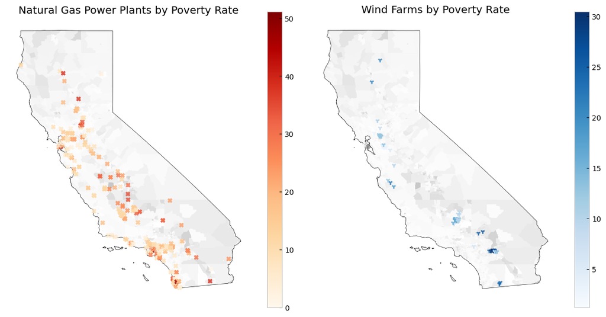

```python
# Create subplots
fig, (ax1,ax2) = plt.subplots(1, 2, figsize=(12, 6))

# Plot natural gas
outlines.plot(ax=ax1, color='white', edgecolor='black')
ax1.set_title("Natural Gas Power Plants by Poverty Rate")
hb1 = ca_poverty_tract.plot(column = "Poverty_Rate",ax = ax1,cmap = "Greys",legend = False, alpha = 0.3)
merged_natgas.plot(column = "Poverty_Rate",ax = ax1,cmap = "OrRd",legend = True, marker='X', alpha = 0.8)

# Plot wind
outlines.plot(ax=ax2, color='white', edgecolor='black')
ax2.set_title("Wind Farms by Poverty Rate")
hb2 = ca_poverty_tract.plot(column = "Poverty_Rate",ax = ax2,cmap = "Greys",legend = False, alpha = 0.3)
merged_wind.plot(column = "Poverty_Rate",ax = ax2, cmap = "Blues",legend = True, marker='1', alpha = 0.8)

# Stylize plots
plt.style.use('bmh')

ax1.axis('off')
ax2.axis('off')
plt.tight_layout()
plt.show()
```

```python
merged_natgas[["Poverty_Rate", "Capacity_Latest"]].corr()
```

|  | Poverty_Rate | Capacity_Latest |
| --- | --- | --- |
| Poverty_Rate | 1.000000 | -0.038935 |
| Capacity_Latest | -0.038935 | 1.000000 |

```python
merged_wind[["Poverty_Rate", "Capacity_Latest"]].corr()
```

[output not shown]

```python
# Extract the columns from the DataFrame
poverty_rate2 = merged_natgas["Poverty_Rate"]
capacity_latest2 = merged_natgas["Capacity_Latest"]

# Calculate Pearson correlation coefficient and p-value
corr_coef2, p_value2 = pearsonr(poverty_rate2, capacity_latest2)

print("Correlation coefficient:", corr_coef2)
print("P-value:", p_value2)
```

```
Correlation coefficient: -0.03893513182385851
P-value: 0.49600525121393324
```

```python
# Extract the columns from the DataFrame
poverty_rate1 = merged_wind["Poverty_Rate"]
capacity_latest1 = merged_wind["Capacity_Latest"]

# Calculate Pearson correlation coefficient and p-value
corr_coef1, p_value1 = pearsonr(poverty_rate1, capacity_latest1)

print("Correlation coefficient:", corr_coef1)
print("P-value:", p_value1)
```

```
Correlation coefficient: -0.2255047329819502
P-value: 0.006205773737400186
```

```python
# Generate data breaks and color stops from colorBrewer
color_breaks1 = [round(merged_natgas['Poverty_Rate'].quantile(q=x*0.1), 2) for x in range(1, 6)]
color_breaks2 = [round(merged_wind['Poverty_Rate'].quantile(q=x*0.1), 2) for x in range(1, 6)]
color_stops1 = create_color_stops(color_breaks1, colors='OrRd')
color_stops2 = create_color_stops(color_breaks2, colors='Blues')

# Generate radius breaks from data domain and circle-radius range
radius_breaks1 = [round(merged_natgas['Capacity_Latest'].quantile(q=x*0.1), 2) for x in range(2, 7)]
radius_breaks2 = [round(merged_wind['Capacity_Latest'].quantile(q=x*0.1), 2) for x in range(2, 7)]
radius_stops1 = create_radius_stops(radius_breaks1, .5, 10)
radius_stops2 = create_radius_stops(radius_breaks2, .5, 10)

# Create the viz
viz1 = GraduatedCircleViz(merged_natgas_geo,
                          access_token=token,
                          color_property="Poverty_Rate",
                          color_stops=color_stops1,
                          radius_property="Capacity_Latest",
                          radius_stops=radius_stops1,
                          stroke_color='black',
                          stroke_width=0.5,
                          center=(-119, 37),
                          zoom=5,
                          opacity=0.75,
                          below_layer='waterway-label')

viz2 = GraduatedCircleViz(merged_wind_geo,
                          access_token=token,
                          color_property="Poverty_Rate",
                          color_stops=color_stops2,
                          radius_property="Capacity_Latest",
                          radius_stops=radius_stops2,
                          stroke_color='black',
                          stroke_width=0.5,
                          center=(-119, 37),
                          zoom=5,
                          opacity=0.75,
                          below_layer='waterway-label')

viz1.show()
viz2.show()
```

[interactive chart not shown]